# Problem Set 3

Author

Xavier Vortigern

Published

October 28, 2026

#### GitHub Repo: https://github.com/xa-v1/ec422_ps3_vortigern

## 1. Time and Tsibbles

We work with two main datasets: retail_ts and can_gas.

- retail_ts is a time series sourced from FRED. It contains both seasonally adjusted (RSAFS) and non-seasonally adjusted (RSAFSNA) retail sales in millions of dollars, monthly from January 1992 through September 2026.
- can_gas is a time series that comes pre-loaded in R’s fpp3 package. It contains the volume of Canadian natural gas production, measured in billions of cubic meters, monthly from January 1960 to February 2005.

```r
retail_raw <- read_csv(
  "data/retail_sales_raw.csv",
  na = ".",
  col_types = cols(
    observation_date = col_date(format = "%Y-%m-%d"),
    RSAFS = col_double(),
    RSAFSNA = col_double()
  )
)

retail_raw_long <- retail_raw |>
  select(observation_date, RSAFS, RSAFSNA) |>
  pivot_longer(cols = c(RSAFS, RSAFSNA), names_to = "series_id", values_to = "sales")

retail_ts <- retail_raw_long |>
  mutate(Month = yearmonth(observation_date)) |>
  as_tsibble(index = Month, key = series_id)

head(retail_ts)
```

```
# A tsibble: 6 x 4 [1M]
# Key:       series_id [1]
  observation_date series_id  sales    Month
  <date>           <chr>      <dbl>    <mth>
1 1992-01-01       RSAFS     159177 1992 Jan
2 1992-02-01       RSAFS     159189 1992 Feb
3 1992-03-01       RSAFS     158647 1992 Mar
4 1992-04-01       RSAFS     159921 1992 Apr
5 1992-05-01       RSAFS     160471 1992 May
6 1992-06-01       RSAFS     161205 1992 Jun
```

```r
has_gaps(retail_ts)
```

```
# A tibble: 2 × 2
  series_id .gaps
  <chr>     <lgl>
1 RSAFS     FALSE
2 RSAFSNA   FALSE
```

```r
key_vars(canadian_gas)
```

```
character(0)
```

```r
index_var(canadian_gas)
```

```
[1] "Month"
```

```r
can_gas <- canadian_gas |>
  select(Month, Volume)

has_gaps(can_gas)
```

```
# A tibble: 1 × 1
  .gaps
  <lgl>
1 FALSE
```

```r
head(can_gas)
```

```
# A tsibble: 6 x 2 [1M]
     Month Volume
     <mth>  <dbl>
1 1960 Jan   1.43
2 1960 Feb   1.31
3 1960 Mar   1.40
4 1960 Apr   1.17
5 1960 May   1.12
6 1960 Jun   1.01
```

```r
can_gas_recent <- can_gas |>
  filter(Month >= yearmonth("1990 Jan"))

can_gas_recent <- can_gas_recent |>
  mutate(year    = year(Month),
         month   = month(Month, label = TRUE),
         quarter = quarter(Month))

can_gas_recent |>
  as_tibble() |>
  group_by(month) |>
  summarize(avg_volume = mean(Volume))
```

```
# A tibble: 12 × 2
   month avg_volume
   <ord>      <dbl>
 1 Jan         17.0
 2 Feb         15.3
 3 Mar         16.3
 4 Apr         15.7
 5 May         15.7
 6 Jun         14.9
 7 Jul         15.6
 8 Aug         15.6
 9 Sep         15.1
10 Oct         16.2
11 Nov         16.2
12 Dec         17.1
```

December has the highest average production (17.1), June has the lowest (14.9)

```r
can_gas_recent |>
  mutate(next_month           = Month + 1,
         same_month_last_year = Month - 12) |>
  head()
```

```
# A tsibble: 6 x 7 [1M]
     Month Volume  year month quarter next_month same_month_last_year
     <mth>  <dbl> <dbl> <ord>   <int>      <mth>                <mth>
1 1990 Jan   12.5  1990 Jan         1   1990 Feb             1989 Jan
2 1990 Feb   11.2  1990 Feb         1   1990 Mar             1989 Feb
3 1990 Mar   11.6  1990 Mar         1   1990 Apr             1989 Mar
4 1990 Apr   11.1  1990 Apr         2   1990 May             1989 Apr
5 1990 May   11.0  1990 May         2   1990 Jun             1989 May
6 1990 Jun   10.1  1990 Jun         2   1990 Jul             1989 Jun
```

```r
can_gas_q <- can_gas |>
  filter(Month <= yearmonth("2004 Dec")) |>
  index_by(Quarter = yearquarter(Month)) |>
  summarize(Volume = sum(Volume))

head(can_gas_q)
```

```
# A tsibble: 6 x 2 [1Q]
  Quarter Volume
    <qtr>  <dbl>
1 1960 Q1   4.14
2 1960 Q2   3.30
3 1960 Q3   2.97
4 1960 Q4   4.26
5 1961 Q1   5.01
6 1961 Q2   4.17
```

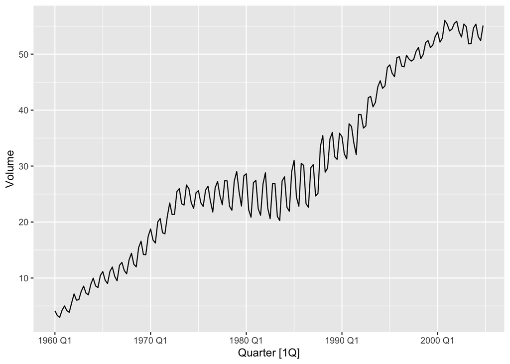

```r
can_gas_q |> autoplot(Volume)
```

We sum the monthly values rather than averaging them because this gives us the production over the entire quarter, which is more useful for analysis than the monthly average across the quarter. Yes, the quarterly data still does appear to be seasonal as the production is typically high in Q1, falls off through Q2 and Q3, and then rises again in Q4.

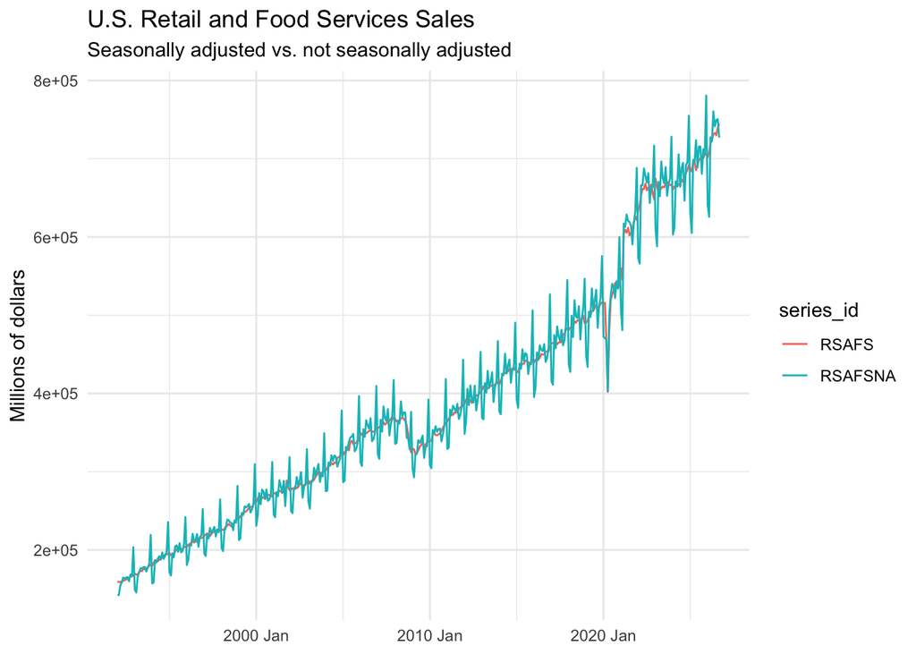

```r
retail_ts |>
  autoplot(sales) +
  labs(
    title = "U.S. Retail and Food Services Sales",
    subtitle = "Seasonally adjusted vs. not seasonally adjusted",
    x = NULL, y = "Millions of dollars", color = NULL
  ) +
  theme_minimal()
```

Visually, the season adjustment greatly smooths out the series. Retail sales see a spike every year in December due to Christmas, however this spike is not present in the seasonally adjusted series. Overall they follow the same trend, and the recessions are obvious in both series, arguably easier to see in the adjusted series.

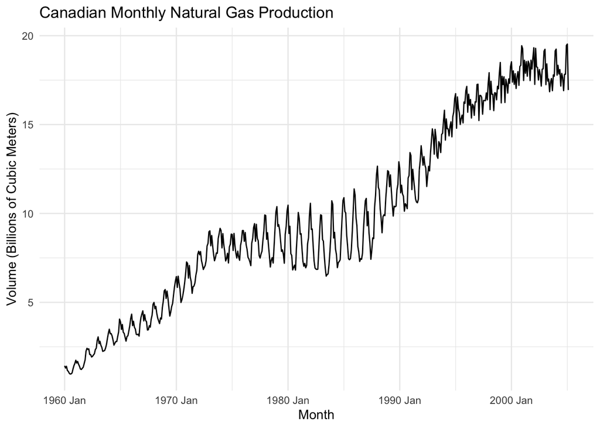

```r
can_gas |>
  autoplot(Volume) +
  labs(
    title = "Canadian Monthly Natural Gas Production",
    x = "Month", y = "Volume (Billions of Cubic Meters)", color = NULL
  ) +
  theme_minimal()
```

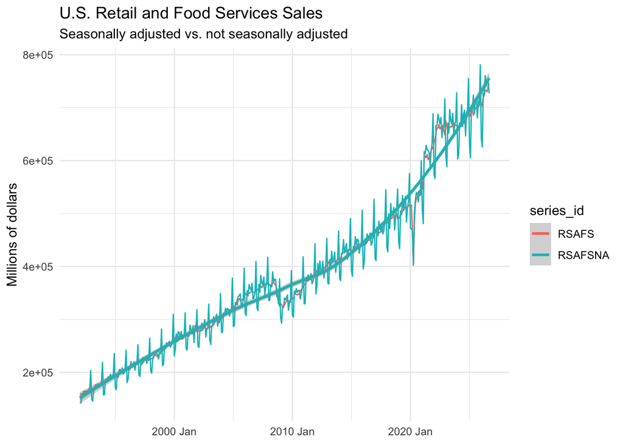

```r
retail_ts |>
  autoplot(sales) +
  geom_smooth() +
  labs(
    title = "U.S. Retail and Food Services Sales",
    subtitle = "Seasonally adjusted vs. not seasonally adjusted",
    x = NULL, y = "Millions of dollars", color = NULL
  ) +
  theme_minimal()
```

I added a trend line with geom_smooth() to see if the recessions caused noticeable dips in the overall upward trend of the series.

## 2. Transformations

The swings get bigger roughly between 1975-1990. Before that they are relatively constant in magnitude, and constant in magnitude after as well, although they are choppier, seemingly meaning that the swings happen faster.

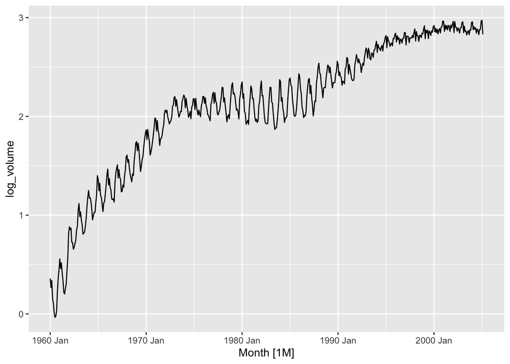

```r
can_gas <- can_gas |> mutate(log_volume = log(Volume))

can_gas |> autoplot(log_volume)
```

After logging, the size differences in the swings are more obvious. They start out relatively large, get smaller around 1973, then get bigger between 1975-1990, and shrink considerably after 1990. After logging, the trend also shows much faster growth early on, and then slows down around 1975. Based on this, I don’t think logging is a great option for this series because the size of the swings don’t grow with the level, and instead grow and shrink in the middle of the series.

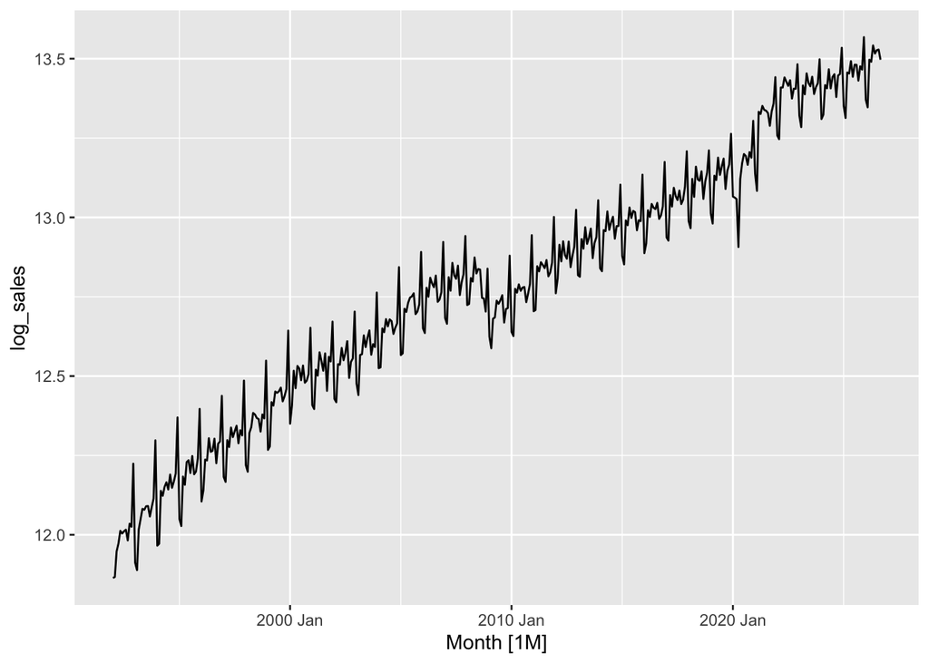

```r
retail_log_nsa <- retail_ts |> filter(series_id == "RSAFSNA") |> mutate(log_sales = log(sales))

retail_log_nsa |> autoplot(log_sales)
```

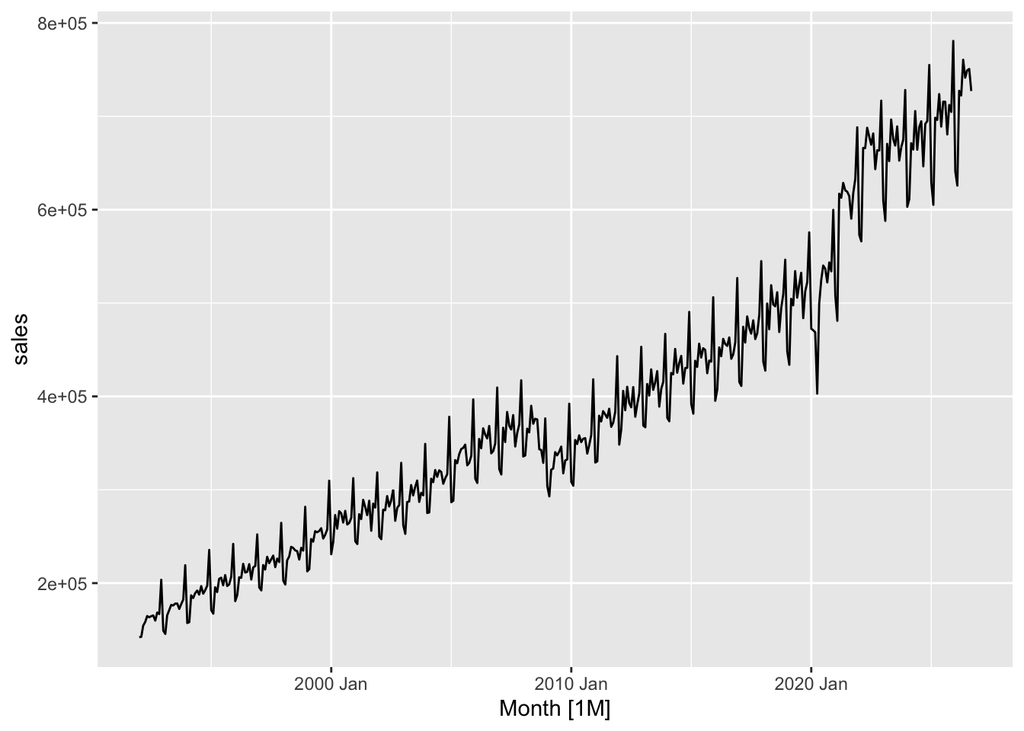

```r
retail_log_nsa |> autoplot(sales)
```

In my opinion, the case for logging is stronger for the retail series. The swings fan out over time for the non-logged series, and taking the log reveals a more consistent swing size over time.

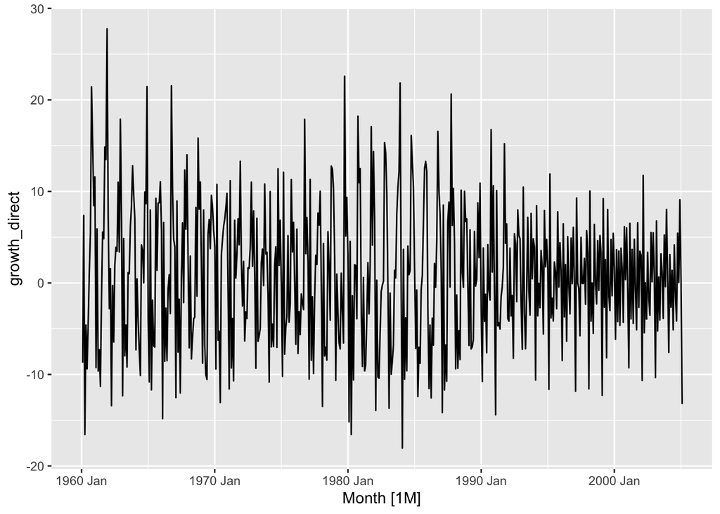

```r
can_gas <- can_gas |> mutate( growth_direct = 100 * difference(Volume) / lag(Volume), growth_logdiff = 100 * difference(log_volume) )

can_gas |> autoplot(growth_direct)
```

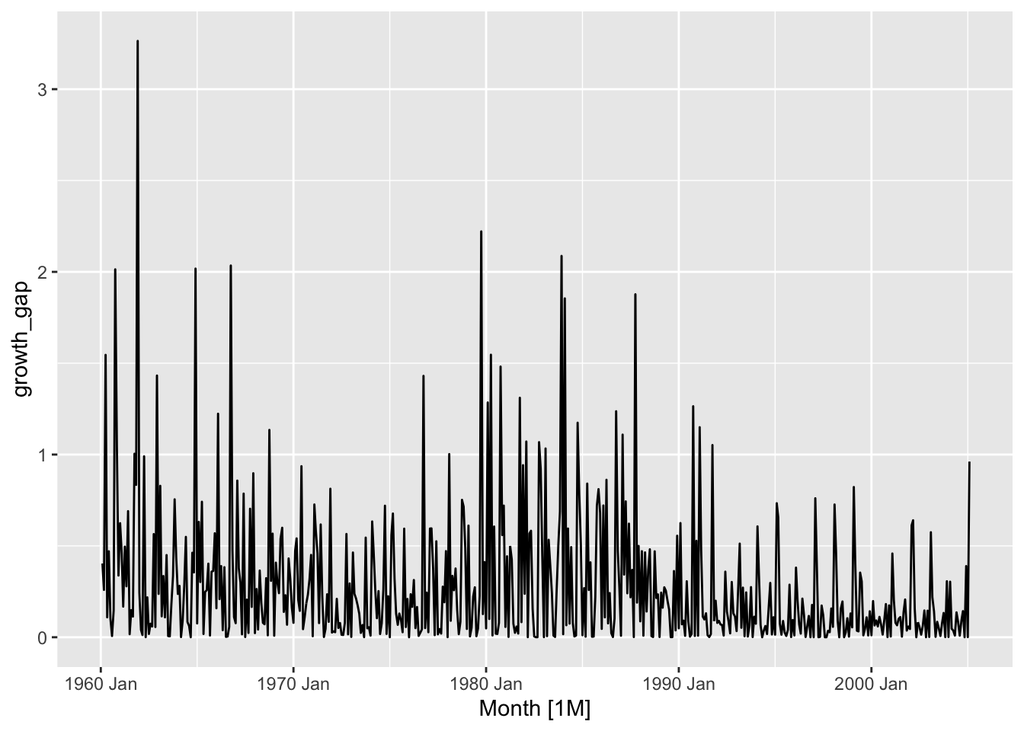

```r
can_gas <- can_gas |> mutate(growth_gap = abs(growth_direct - growth_logdiff))

can_gas |> autoplot(growth_gap)
```

The log difference approach does alright in this case, being within 1% of the exact growth rate for most of the series, but I would prefer the exact growth rate for the sake of preciseness.

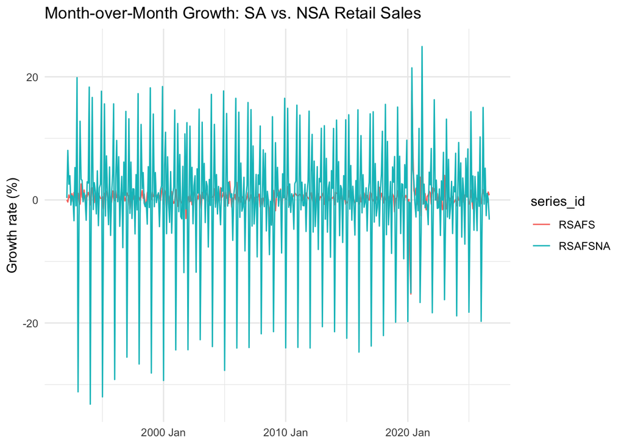

```r
retail_ts <- retail_ts |> group_by_key() |> mutate(growth_mom = 100 * difference(log(sales))) |> ungroup()

retail_ts |> autoplot(growth_mom) + labs( title = "Month-over-Month Growth: SA vs. NSA Retail Sales", x = NULL, y = "Growth rate (%)", color = NULL ) + theme_minimal()
```

As expected, the seasonally adjusted series has a much smoother MoM growth rate. The December spikes in the non-adjusted series create big growth rate spikes which are not present in the adjusted series.

## 3. Seasonality

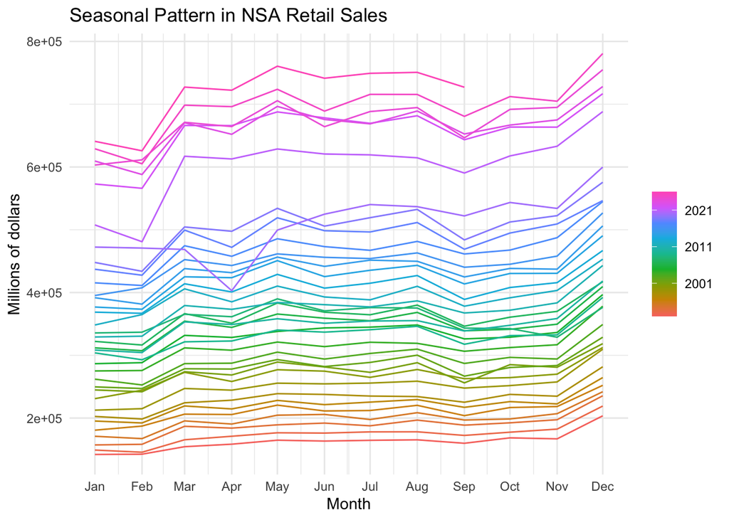

```r
retail_ts |> filter(series_id == "RSAFSNA") |> gg_season(sales) + labs( title = "Seasonal Pattern in NSA Retail Sales", y = "Millions of dollars" ) + theme_minimal()
```

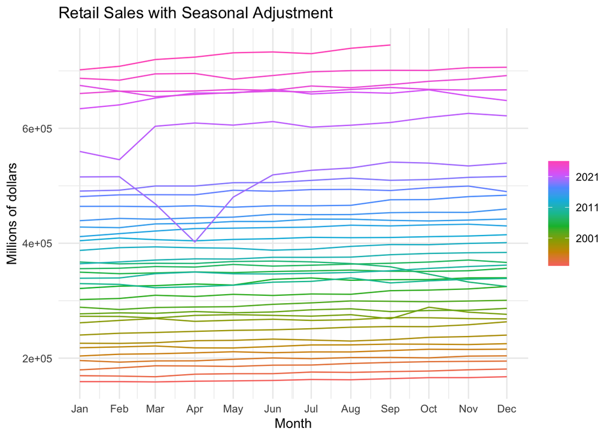

```r
retail_ts |> filter(series_id == "RSAFS") |> gg_season(sales) + labs( title = "Retail Sales with Seasonal Adjustment", y = "Millions of dollars" ) + theme_minimal()
```

The NSA plot very clearly shows the pattern of sales increasing in December. The seasonally adjusted plot has removed this pattern, making sales throughout the year much more flat.

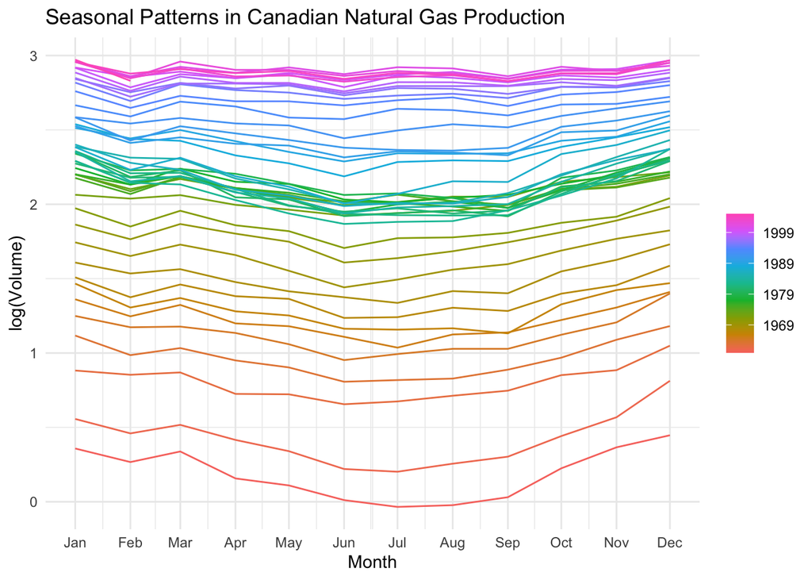

```r
can_gas |> gg_season(log_volume) + labs( title = "Seasonal Patterns in Canadian Natural Gas Production", y = "log(Volume)" ) + theme_minimal()
```

The seasonal pattern depends on weather conditions in this case, since natural gas is often used for heating. It tends to be highest in December and January when it is coldest outside, and lowest in June, July, and August during the peak of summer heat.

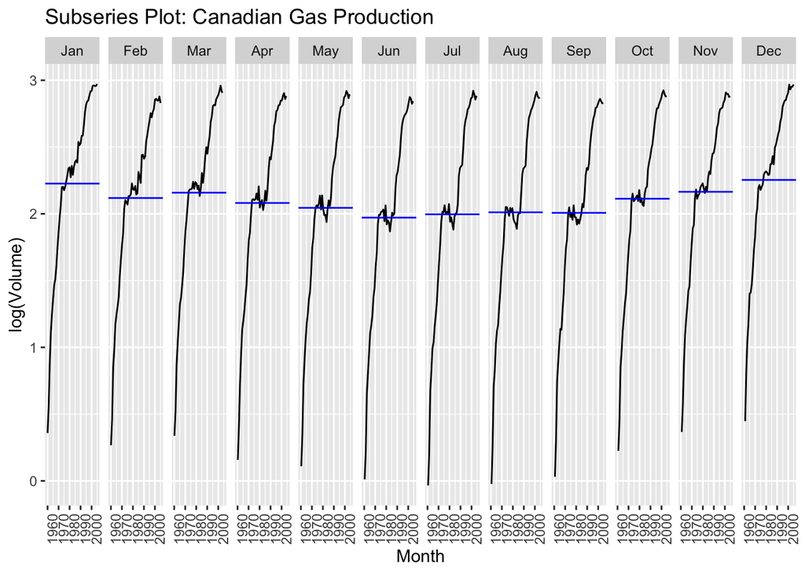

```r
can_gas |> gg_subseries(log_volume) + labs( title = "Subseries Plot: Canadian Gas Production", y = "log(Volume)" )
```

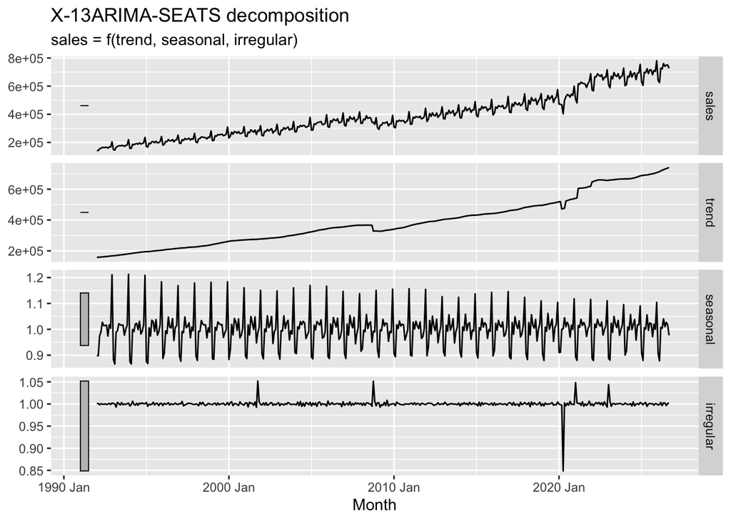

```r
retail_nsa_x13 <- retail_ts |> filter(series_id == "RSAFSNA") |> model(x13 = X_13ARIMA_SEATS(sales)) |> components()

retail_nsa_x13 |> autoplot()
```

The seasonal factor is highest in December of 1993, with a seasonal value of 1.213, meaning that sales in this month were 21.3% higher than the trend. The size of the seasonal swings appears to get smaller over time.

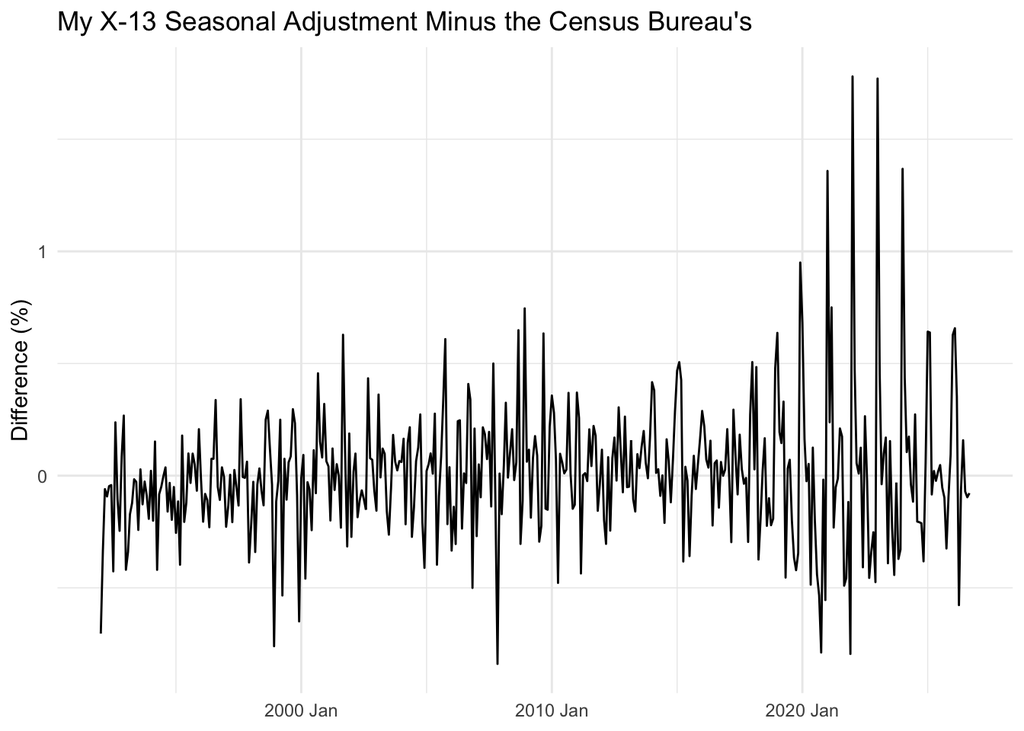

```r
sa_compare <- retail_nsa_x13 |> as_tibble() |> select(Month, mine = season_adjust) |> left_join( retail_ts |> filter(series_id == "RSAFS") |> as_tibble() |> transmute(Month, census = sales), by = "Month" ) |> mutate(pct_diff = 100 * (log(mine) - log(census)))

sa_compare |> ggplot(aes(x = Month, y = pct_diff)) + geom_line() + labs( title = "My X-13 Seasonal Adjustment Minus the Census Bureau's", x = NULL, y = "Difference (%)" ) + theme_minimal()
```

Overall, my seasonal adjustment matches the Census Bureau’s well, with the difference being less than 1% for most of the series. The difference is largest during the “irregular” periods from my model, meaning that the Census Bureau must adjust for outliers different than the base model I used.

```r
can_gas_fit <- can_gas |> model(TSLM(log_volume ~ trend() + season()))

report(can_gas_fit)
```

```
Series: log_volume
Model: TSLM

Residuals:
      Min        1Q    Median        3Q       Max
-0.985307 -0.096451 -0.004525  0.131639  0.470564

Coefficients:
                 Estimate Std. Error t value Pr(>|t|)
(Intercept)     1.150e+00  4.142e-02  27.761  < 2e-16 ***
trend()         3.973e-03  6.886e-05  57.692  < 2e-16 ***
season()year2  -1.121e-01  5.229e-02  -2.144  0.03245 *
season()year3  -5.238e-02  5.258e-02  -0.996  0.31963
season()year4  -1.334e-01  5.258e-02  -2.537  0.01146 *
season()year5  -1.738e-01  5.258e-02  -3.305  0.00101 **
season()year6  -2.512e-01  5.258e-02  -4.777 2.30e-06 ***
season()year7  -2.300e-01  5.258e-02  -4.374 1.47e-05 ***
season()year8  -2.193e-01  5.258e-02  -4.170 3.56e-05 ***
season()year9  -2.274e-01  5.258e-02  -4.325 1.83e-05 ***
season()year10 -1.253e-01  5.258e-02  -2.383  0.01753 *
season()year11 -7.781e-02  5.258e-02  -1.480  0.13956
season()year12  7.202e-03  5.258e-02   0.137  0.89111
---
Signif. codes:  0 '***' 0.001 '**' 0.01 '*' 0.05 '.' 0.1 ' ' 1

Residual standard error: 0.2508 on 529 degrees of freedom
Multiple R-squared: 0.8652, Adjusted R-squared: 0.8622
F-statistic:   283 on 12 and 529 DF, p-value: < 2.22e-16
```

```r
can_gas_fit |> tidy() |> select(term, estimate, std.error, statistic, p.value) |> knitr::kable(digits = 3)
```

| term | estimate | std.error | statistic | p.value |
| --- | --- | --- | --- | --- |
| (Intercept) | 1.150 | 0.041 | 27.761 | 0.000 |
| trend() | 0.004 | 0.000 | 57.692 | 0.000 |
| season()year2 | -0.112 | 0.052 | -2.144 | 0.032 |
| season()year3 | -0.052 | 0.053 | -0.996 | 0.320 |
| season()year4 | -0.133 | 0.053 | -2.537 | 0.011 |
| season()year5 | -0.174 | 0.053 | -3.305 | 0.001 |
| season()year6 | -0.251 | 0.053 | -4.777 | 0.000 |
| season()year7 | -0.230 | 0.053 | -4.374 | 0.000 |
| season()year8 | -0.219 | 0.053 | -4.170 | 0.000 |
| season()year9 | -0.227 | 0.053 | -4.325 | 0.000 |
| season()year10 | -0.125 | 0.053 | -2.383 | 0.018 |
| season()year11 | -0.078 | 0.053 | -1.480 | 0.140 |
| season()year12 | 0.007 | 0.053 | 0.137 | 0.891 |

The estimated average monthly growth rate of gas production is 0.4%, and June has the most significant seasonal affect, holding the largest absolute value of it’s coefficient relative to January, as well as the highest t-statistic.

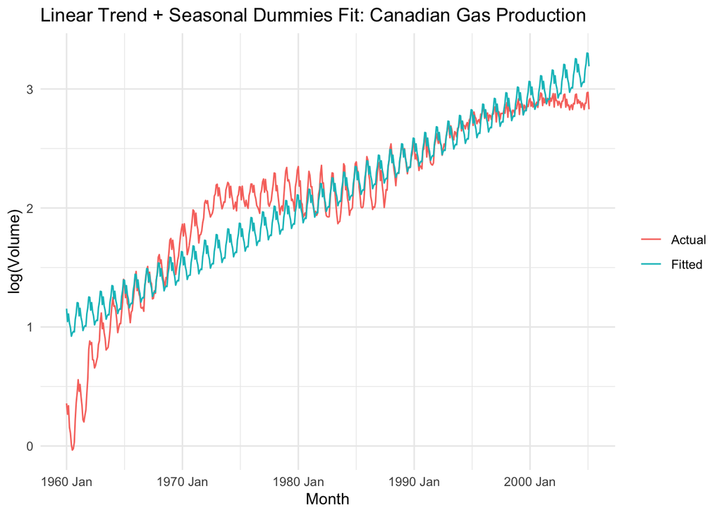

```r
can_gas_fit |> augment() |> ggplot(aes(x = Month)) + geom_line(aes(y = log_volume, color = "Actual")) + geom_line(aes(y = .fitted, color = "Fitted")) + labs(title = "Linear Trend + Seasonal Dummies Fit: Canadian Gas Production", y = "log(Volume)", color = NULL) + theme_minimal()
```

The line does a pretty poor job of tracking the series. It misses most of the actual series between 1960-1985, and only tracks it well after this point (other than the falloff starting in the 2000s).

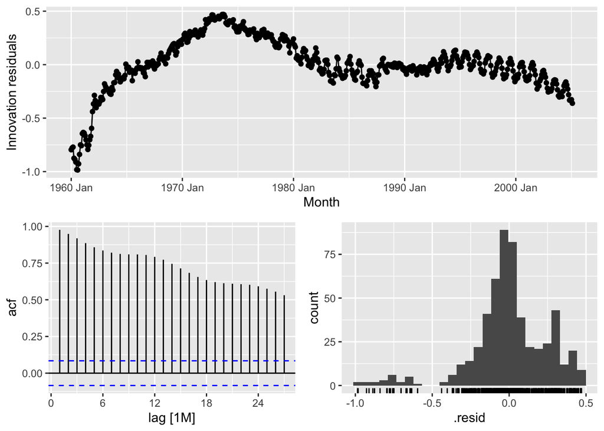

```r
can_gas_fit |> gg_tsresiduals()
```

```r
can_gas_fit |> augment() |> features(.innov, ljung_box, lag = 24)
```

```
# A tibble: 1 × 3
  .model                                lb_stat lb_pvalue
  <chr>                                   <dbl>     <dbl>
1 TSLM(log_volume ~ trend() + season())   7774.         0
```

No, the residuals definitely do not look like white noise. They have an obvious structure and we can even see seasonal swings in the residuals starting around 1995. The ACF also starts close to 1 and decays slowly. The Ljung-Box test confirms this at the 5% level, with a statistic of 7774 and a p-value of essentially 0.

## 4. Forecast Evaluation

```r
gas_cv_fc <- can_gas |> select(Month, Volume) |> stretch_tsibble(.init = 240, .step = 1) |> model(snaive = SNAIVE(Volume), tslm = TSLM(log(Volume) ~ trend() + season())) |> forecast(h = 1)

acc <- gas_cv_fc |> accuracy(can_gas, measures = list(MAE = MAE, RMSE = RMSE))

acc |>
  knitr::kable(digits = 2)
```

| .model | .type | MAE | RMSE |
| --- | --- | --- | --- |
| snaive | Test | 0.56 | 0.70 |
| tslm | Test | 4.01 | 4.36 |

The first forecast is evaluated on Jan 1980, and the last is on February 2005. The seasonal random walk model reports more accurately, as both the MAE and RMSE are smaller.

```r
errs <- gas_cv_fc |> as_tibble() |> left_join(as_tibble(can_gas) |> select(Month, actual = Volume), by = "Month") |> mutate(e = actual - .mean) |> select(Month, .model, e) |> pivot_wider(names_from = .model, values_from = e) |> na.omit()

forecast::dm.test(errs$snaive, errs$tslm, h = 1, power = 1)
```

```
    Diebold-Mariano Test

data:  errs$snaiveerrs$tslm
DM = -31.278, Forecast horizon = 1, Loss function power = 1, p-value <
2.2e-16
alternative hypothesis: two.sided
```

The large negative DM stat value indicates that the seasonal random walk model has statistically significantly lower forecast errors than the linear trend + seasonal dummies model.

```r
gas_cv_fc_rolling <- can_gas |> select(Month, Volume) |> slide_tsibble(.size = 240, .step = 1) |> model(snaive = SNAIVE(Volume), tslm = TSLM(log(Volume) ~ trend() + season())) |> forecast(h = 1)

accuracy_results <- gas_cv_fc_rolling |>
  accuracy(can_gas, measures = list(MAE = MAE, RMSE = RMSE))

accuracy_results |>
  knitr::kable(digits = 2)
```

| .model | .type | MAE | RMSE |
| --- | --- | --- | --- |
| snaive | Test | 0.56 | 0.70 |
| tslm | Test | 2.09 | 2.42 |

The linear trend + seasonal dummies model had a bigger change in accuracy when changing from an expanding window to a rolling window, with the MAE cut roughly in half and the RMSE cut almost in half. One reason why this might be is because the growth rate of gas production has slowed down over time, so using a rolling window allows the model to stop considering the older, faster growth rate, and adjust to the slower growth rate later on.

## 5. Reflection

The residuals from the simple trend + seasonal model look like they missed a couple of features. First, we can still see seasonal swings in the series, meaning that our constant seasonality assumption does not capture how the seasonal swings actually evolve. For example, they become much more rapid around the 90s, which our fitted model does not account for. Assuming a constant trend also means that our fitted model misses the changing growth rates seen in the actual model, so our residual show structure for this reason as well. I think a model that captures this structure might use rolling windows when assessing seasonal swings and trends, since the time series is extremely long and assuming that relationships will stay constant throughout leaves us with a bad fit.